# Practical Machine Learning Project - Predicting how well an activity would be performed

## Synopsis

Using devices such as Jawbone Up, Nike FuelBand, and Fitbit it is now possible to collect a large amount of data about personal activity relatively inexpensively. These type of devices are part of the quantified self movement - a group of enthusiasts who take measurements about themselves regularly to improve their health, to find patterns in their behavior, or because they are tech geeks. One thing that people regularly do is quantify how much of a particular activity they do, but they rarely quantify how well they do it. In this project, my goal will be to use data from accelerometers on the belt, forearm, arm, and dumbell of 6 participants. They were asked to perform barbell lifts correctly and incorrectly in 5 different ways. More information is available from the website here: http://groupware.les.inf.puc-rio.br/har (see the section on the Weight Lifting Exercise Dataset).

```r
library("caret")
library("rpart")
library("knitr")
```

```r
opts_chunk$set(echo=TRUE)
```

## Data Preparation and Cleaning

- The training and testing data were first downloaded from the Coursera course site.Then they are read into R.

```r
data<-read.csv("./train.csv",na.strings = c("NA",""))
test<-read.csv("./test.csv",na.strings = c("NA",""))
```

- After some quick data exploration using str(data), it is found that the dataset has many variables with high % of NAs, which might not make them suitable as predictors.So we attempt to check and remove variables with high proportion of NAs.

```r
x<-(colSums(!is.na(data)));summary(x)
```

```
##    Min. 1st Qu.  Median    Mean 3rd Qu.    Max.
##     406     406     406    7612   19620   19620
```

```r
datanew<-data[,x>min(x)]
```

- Then we check and remove zero covariates, if any.

```r
nsv<-nearZeroVar(datanew,saveMetrics=TRUE)
datanew<- datanew[, !nsv$nzv]
```

- We also remove variables that will most likely be not useful for the model

```r
datanew<-datanew[,-c(1:6)]
```

- Lastly we try to check for correlated variables.

```r
M<-abs(cor(datanew[,-dim(datanew)[2]]))
diag(M)<-0
y<-which(M>0.8,arr.ind=T)
z<-unique(dimnames(y)[[1]])
```

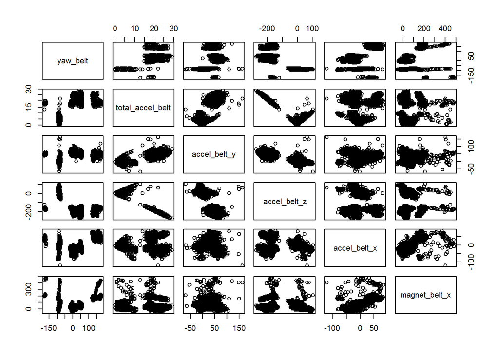

```r
pairs(datanew[,head(z)])
```

## Data Modeling

This is clearly a classification problem so naturally we started by trying decision tree modeling. For the decision tree modelling,we use k-fold cross validation where k=10

```r
dtFit<-rpart(classe~.,method="class",data=datanew,control = rpart.control(cp=0.01, xval = 10))
printcp(dtFit)
```

```
##
## Classification tree:
## rpart(formula = classe ~ ., data = datanew, method = "class",
##     control = rpart.control(cp = 0.01, xval = 10))
##
## Variables actually used in tree construction:
##  [1] accel_dumbbell_y     accel_dumbbell_z     accel_forearm_x
##  [4] magnet_arm_y         magnet_belt_z        magnet_dumbbell_y
##  [7] magnet_dumbbell_z    magnet_forearm_z     pitch_belt
## [10] pitch_forearm        roll_belt            roll_dumbbell
## [13] roll_forearm         total_accel_dumbbell yaw_belt
## [16] yaw_forearm
##
## Root node error: 14042/19622 = 0.71563
##
## n= 19622
##
##          CP nsplit rel error  xerror      xstd
## 1  0.115155      0   1.00000 1.00000 0.0045002
## 2  0.059987      1   0.88485 0.88485 0.0048075
## 3  0.035679      4   0.70489 0.70517 0.0049876
## 4  0.029839      5   0.66921 0.67455 0.0049849
## 5  0.021934      6   0.63937 0.64122 0.0049709
## 6  0.020083     11   0.51531 0.53297 0.0048455
## 7  0.020011     12   0.49523 0.49323 0.0047673
## 8  0.019228     13   0.47522 0.48440 0.0047475
## 9  0.016807     14   0.45599 0.46461 0.0046996
## 10 0.013460     15   0.43918 0.44694 0.0046528
## 11 0.010789     16   0.42572 0.42067 0.0045759
## 12 0.010255     21   0.36184 0.38029 0.0044398
## 13 0.010113     22   0.35159 0.36327 0.0043755
## 14 0.010000     23   0.34148 0.36021 0.0043634
```

The error rate for plain vanilla decision tree model is fairly high. Therefore, we proceed to try random forest which, fundamentally, is decision tree modeling but with bootstrap sampling and growth of multiple trees.

```r
set.seed(123)
rfFit <- train(classe ~ ., method = "rf", data = training, importance = T)
rfFit
```

```
## Random Forest
##
## 13737 samples
##    52 predictor
##     5 classes: 'A', 'B', 'C', 'D', 'E'
##
## No pre-processing
## Resampling: Bootstrapped (25 reps)
##
## Summary of sample sizes: 13737, 13737, 13737, 13737, 13737, 13737, ...
##
## Resampling results across tuning parameters:
##
##   mtry  Accuracy   Kappa      Accuracy SD  Kappa SD
##    2    0.9875533  0.9842473  0.001968057  0.002484698
##   27    0.9879967  0.9848100  0.002187379  0.002762621
##   52    0.9786301  0.9729566  0.004960808  0.006269994
##
## Accuracy was used to select the optimal model using  the largest value.
## The final value used for the model was mtry = 27.
```

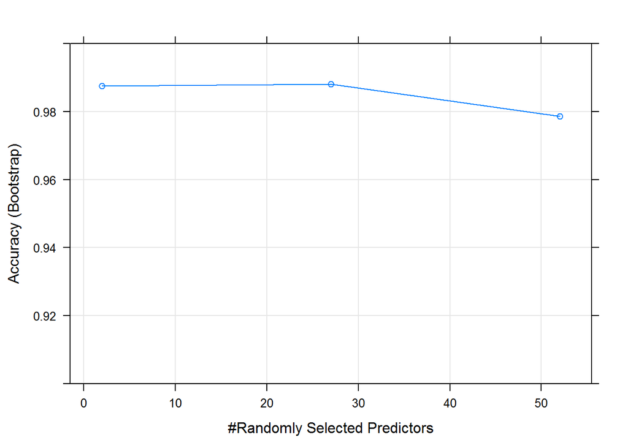

```r
plot(rfFit, ylim = c(0.9, 1))
```

```r
print(rfFit$finalModel)
```

```
##
## Call:
##  randomForest(x = x, y = y, mtry = param$mtry, importance = ..1)
##                Type of random forest: classification
##                      Number of trees: 500
## No. of variables tried at each split: 27
##
##         OOB estimate of  error rate: 0.68%
## Confusion matrix:
##      A    B    C    D    E class.error
## A 3902    3    1    0    0 0.001024066
## B   20 2628    6    4    0 0.011286682
## C    0   12 2375    9    0 0.008764608
## D    0    1   23 2228    0 0.010657194
## E    0    1    5    8 2511 0.005544554
```

```r
ImpVar<-varImp(rfFit$finalModel, useModel = TRUE, nonpara = TRUE, scale = TRUE)
w<-order(-apply(ImpVar,1,mean))
Var<-dimnames(ImpVar)[[1]][head(w)]
```

In random forests, there is no need for cross-validation or a separate test set to get an unbiased estimate of the test set error. It is estimated internally during the run. In this case, the out-of-bag (oob) error estimate which is also the out of sample error rate is 0.7%. The six most important predictors are roll_belt, pitch_forearm, magnet_dumbbell_y,magnet_dumbbell_z,yaw_belt and pitch_belt.

Since error rate of the random forest model is very low, we choose the random forest model.

## Prediction

```r
prediction <- as.character(predict(rfFit, test))
```

## Exporting prediction files

```r
pml_write_files = function(x){
        n = length(x)
        for(i in 1:n){
                filename = paste0("./problem_id_", i, ".txt")
                write.table(x[i], file = filename, quote = FALSE, row.names = FALSE, col.names = FALSE)
        }
}
pml_write_files(prediction)
```